# Student Experiences In Academic Environments

Author

Yulia Ivanytskyy

## Overview of the Report

This reproducible report documents the workflow from the original Qualtrics survey data. It includes several components of this study including data preperation, variable construction, descriptive statistics, reliability testsm and final analysis.

This report goes hand in hand with a research paper, showing how the reported analyses were produced from the data set using a transparent and reproducible Quarto workflow. This is done in order to provide understanding on how the data was prepare and used to reach the final results.

## Overview of the Study

This study aims to determine whether different types of academic feedback (autonomy-supportive or controlling) have an impact on a college students’ achievement motivation and self-efficacy and whether parental warmth moderates these effects.

This study used a between-subjects design and included one independent variable, one moderator and two dependent variables.

The independent variable was the types of academic feedback: controlling or autonomy-supportive.

The dependent variables were self-efficacy and achievement motivation measured using the General Self-Efficacy Scale (GSE) and Ray’s Achievement Motivation Scale (RAM).

## **Setup and Software Environment**

The packages were loaded to ensure that the analysis will run smoothly with no interruption. The import of these packages allowed for support with scale construction, statistical modeling and visualization.

**Load packages**

```r
# Load data manipulation tools
library(tidyverse)  # includes dplyr, readr, etc.

# Load scale construction tools
library(psych)  # functions for scale analysis

# Load analysis tools for later labs
library(afex)  # ANOVA models
library(emmeans)  # estimated marginal means
```

## Data Source and Preparation

In this section, the data set was imported into R successfully. The data was improted from the data folder and saved as study_data in order to be cleaned and used by R.

The data for this study was collected through Qualtrics in the form of questionnaires.

### **Load Data**

```r
study_data <- read.csv("data/group_7_developmental.csv")
head(study_data)
```

```
         ResponseId DistributionChannel Consent
1 R_7KOR2s3Am6wuIsh           anonymous       1
2 R_5HEJrS3Dpv5O1Nf           anonymous       1
3 R_1BscAKP7SLvVrVf               email       1
4 R_5D15R84Vc2nR9sq               email       1
5 R_1ZHTOlNvXCFZj7i               email       1
6 R_3xz1r04h0Dgwf5K           anonymous       1
                                                                                                                                                                                                                                                                                                            …
1
2 I would take this feedback and rework my thesis draft. Personally, I'd make a copy and leave my work, which is more concise and easier for me to read, but I would adhere to the professor's advice of making them into two separate chapters. This feedback would not make me feel any form of negativity…
3
4                                                                                                                                                                                                                                                      I feel somewhat defeated because it does not feel goo…
5
6
                                                                                                                                                                                Autonomy.Writing
```

[output cut: 55 more lines]

```r
# Preview the first few rows of the dataset
head(study_data)  # displays first rows to confirm structure and values
```

```
         ResponseId DistributionChannel Consent
1 R_7KOR2s3Am6wuIsh           anonymous       1
2 R_5HEJrS3Dpv5O1Nf           anonymous       1
3 R_1BscAKP7SLvVrVf               email       1
4 R_5D15R84Vc2nR9sq               email       1
5 R_1ZHTOlNvXCFZj7i               email       1
6 R_3xz1r04h0Dgwf5K           anonymous       1
                                                                                                                                                                                                                                                                                                            …
1
2 I would take this feedback and rework my thesis draft. Personally, I'd make a copy and leave my work, which is more concise and easier for me to read, but I would adhere to the professor's advice of making them into two separate chapters. This feedback would not make me feel any form of negativity…
3
4                                                                                                                                                                                                                                                      I feel somewhat defeated because it does not feel goo…
5
6
                                                                                                                                                                                Autonomy.Writing
```

[output cut: 55 more lines]

```r
# Print all variable names in the dataset
names(study_data)  # lists all column names for inspection
```

```
 [1] "ResponseId"          "DistributionChannel" "Consent"
 [4] "Control.Writing"     "Autonomy.Writing"    "GSE._1"
 [7] "GSE._2"              "GSE._3"              "GSE._4"
[10] "GSE._5"              "GSE._6"              "GSE._7"
[13] "GSE._8"              "GSE._9"              "GSE._10"
[16] "RAMS._1"             "RAMS._2"             "RAMS._3"
[19] "RAMS._4"             "RAMS._5"             "RAMS._6"
[22] "RAMS._7"             "RAMS._8"             "RAMS._9"
[25] "RAMS._10"            "RAMS._11"            "RAMS._12"
[28] "RAMS._13"            "RAMS._14"            "PAQ1_1"
[31] "PAQ1_2"              "PAQ1_3"              "PAQ1_4"
[34] "PAQ1_5"              "PAQ1_6"              "PAQ1_7"
[37] "PAQ1_8"              "PAQ1_9"              "PAQ1_10"
[40] "PAQ1_11"             "PAQ1_12"             "PAQ1_13"
[43] "PAQ1_14"             "PAQ1_15"             "PAQ2_1"
[46] "PAQ2_2"              "PAQ2_3"              "PAQ2_4"
[49] "PAQ2_5"              "PAQ2_6"              "PAQ2_7"
[52] "PAQ2_8"              "PAQ2_9"              "PAQ2_10"
[55] "PAQ2_11"             "PAQ2_12"             "PAQ2_13"
[58] "PAQ2_14"             "PAQ2_15"             "Age"
[61] "Gender"              "Gender_4_TEXT"       "Year"
[64] "Year_5_TEXT"         "Debrief"             "Condition"
```

### Data Exclusions

The study contained several unanswered or incomplete data, which resulted from participant leaving segments of the questionnaire blank. To prevent the data from interfering with the analysis, this section was used to exclude all unnecessary data.

```r
#excluding participants w/ missing data
study_data <- study_data %>%
  filter(
    if_all(GSE._1:PAQ2_15,
           ~!is.na(.)
           ))
```

### Check Imported Data Set

```r
dim(study_data)
```

```
[1] 76 66
```

```r
names(study_data)
```

```
 [1] "ResponseId"          "DistributionChannel" "Consent"
 [4] "Control.Writing"     "Autonomy.Writing"    "GSE._1"
 [7] "GSE._2"              "GSE._3"              "GSE._4"
[10] "GSE._5"              "GSE._6"              "GSE._7"
[13] "GSE._8"              "GSE._9"              "GSE._10"
[16] "RAMS._1"             "RAMS._2"             "RAMS._3"
[19] "RAMS._4"             "RAMS._5"             "RAMS._6"
[22] "RAMS._7"             "RAMS._8"             "RAMS._9"
[25] "RAMS._10"            "RAMS._11"            "RAMS._12"
[28] "RAMS._13"            "RAMS._14"            "PAQ1_1"
[31] "PAQ1_2"              "PAQ1_3"              "PAQ1_4"
[34] "PAQ1_5"              "PAQ1_6"              "PAQ1_7"
[37] "PAQ1_8"              "PAQ1_9"              "PAQ1_10"
[40] "PAQ1_11"             "PAQ1_12"             "PAQ1_13"
[43] "PAQ1_14"             "PAQ1_15"             "PAQ2_1"
[46] "PAQ2_2"              "PAQ2_3"              "PAQ2_4"
[49] "PAQ2_5"              "PAQ2_6"              "PAQ2_7"
[52] "PAQ2_8"              "PAQ2_9"              "PAQ2_10"
[55] "PAQ2_11"             "PAQ2_12"             "PAQ2_13"
[58] "PAQ2_14"             "PAQ2_15"             "Age"
[61] "Gender"              "Gender_4_TEXT"       "Year"
[64] "Year_5_TEXT"         "Debrief"             "Condition"
```

This confirms that the data set was loaded successfully and included the number of rows and columns as well as the variable names associated with the variables.

### Create Analysis Dataset

```r
study_vars <- c(
  "Consent",
  "Control.Writing",
  "Autonomy.Writing",

  "GSE._1",
  "GSE._2",
  "GSE._3",
  "GSE._4",
  "GSE._5",
  "GSE._6",
  "GSE._7",
  "GSE._8",
  "GSE._9",
  "GSE._10",

  "RAMS._1",
  "RAMS._2",
  "RAMS._3",
  "RAMS._4",
  "RAMS._5",
  "RAMS._6",
  "RAMS._7",
  "RAMS._8",
  "RAMS._9",
  "RAMS._10",
  "RAMS._11",
  "RAMS._12",
  "RAMS._13",
  "RAMS._14",

  "PAQ1_1",
  "PAQ1_2",
  "PAQ1_3",
  "PAQ1_4",
  "PAQ1_5",
  "PAQ1_6",
  "PAQ1_7",
  "PAQ1_8",
  "PAQ1_9",
  "PAQ1_10",
  "PAQ1_11",
  "PAQ1_12",
  "PAQ1_13",
  "PAQ1_14",
  "PAQ1_15",
  "PAQ2_1",
  "PAQ2_2",
  "PAQ2_3",
  "PAQ2_4",
  "PAQ2_5",
  "PAQ2_6",
  "PAQ2_7",
  "PAQ2_8",
  "PAQ2_9",
  "PAQ2_10",
  "PAQ2_11",
  "PAQ2_12",
  "PAQ2_13",
  "PAQ2_14",
  "PAQ2_15",

  "Age",
  "Gender",
  "Year",
  "Condition"
)
```

### **Prepare the Dataset - Converting Data to Numeric Values**

At this stage, your goal is to ensure all variables are in the correct format.

```r
# Convert all variables to numeric format
study_data <- study_data %>%
  mutate(across(GSE._1:PAQ2_15, as.numeric)) # ensures numeric type for all variables

# Summarize dataset to confirm conversion
summary(study_data) # checks values and missing data
```

```
  ResponseId        DistributionChannel    Consent  Control.Writing
 Length:76          Length:76           Min.   :1   Length:76
 Class :character   Class :character    1st Qu.:1   Class :character
 Mode  :character   Mode  :character    Median :1   Mode  :character
                                        Mean   :1
                                        3rd Qu.:1
                                        Max.   :1
 Autonomy.Writing       GSE._1          GSE._2          GSE._3
 Length:76          Min.   :1.000   Min.   :1.000   Min.   :1.000
 Class :character   1st Qu.:3.000   1st Qu.:2.000   1st Qu.:3.000
 Mode  :character   Median :3.000   Median :3.000   Median :3.000
                    Mean   :3.382   Mean   :2.697   Mean   :3.118
                    3rd Qu.:4.000   3rd Qu.:3.000   3rd Qu.:4.000
                    Max.   :4.000   Max.   :4.000   Max.   :4.000
     GSE._4          GSE._5          GSE._6          GSE._7
 Min.   :2.000   Min.   :2.000   Min.   :2.000   Min.   :1.000
 1st Qu.:3.000   1st Qu.:3.000   1st Qu.:3.000   1st Qu.:2.000
 Median :3.000   Median :3.000   Median :4.000   Median :3.000
 Mean   :3.079   Mean   :3.158   Mean   :3.539   Mean   :2.921
 3rd Qu.:4.000   3rd Qu.:4.000   3rd Qu.:4.000   3rd Qu.:4.000
 Max.   :4.000   Max.   :4.000   Max.   :4.000   Max.   :4.000
     GSE._8          GSE._9         GSE._10        RAMS._1         RAMS._2
 Min.   :1.000   Min.   :1.000   Min.   :1.00   Min.   :1.000   Min.   :1.000
 1st Qu.:2.000   1st Qu.:3.000   1st Qu.:3.00   1st Qu.:1.000   1st Qu.:1.000
 Median :3.000   Median :3.000   Median :3.00   Median :2.000   Median :2.000
 Mean   :2.921   Mean   :3.092   Mean   :3.25   Mean   :1.961   Mean   :2.118
 3rd Qu.:3.000   3rd Qu.:3.250   3rd Qu.:4.00   3rd Qu.:3.000   3rd Qu.:3.000
 Max.   :4.000   Max.   :4.000   Max.   :4.00   Max.   :3.000   Max.   :3.000
    RAMS._3         RAMS._4     RAMS._5         RAMS._6         RAMS._7
 Min.   :1.000   Min.   :1   Min.   :1.000   Min.   :1.000   Min.   :1.00
 1st Qu.:1.000   1st Qu.:1   1st Qu.:1.000   1st Qu.:1.000   1st Qu.:2.00
 Median :1.000   Median :2   Median :1.000   Median :1.000   Median :2.00
 Mean   :1.618   Mean   :2   Mean   :1.618   Mean   :1.658   Mean   :2.25
 3rd Qu.:2.000   3rd Qu.:3   3rd Qu.:2.250   3rd Qu.:2.000   3rd Qu.:3.00
 Max.   :3.000   Max.   :3   Max.   :3.000   Max.   :3.000   Max.   :3.00
    RAMS._8         RAMS._9         RAMS._10        RAMS._11       RAMS._12
 Min.   :1.000   Min.   :1.000   Min.   :1.000   Min.   :1.00   Min.   :1.000
 1st Qu.:1.000   1st Qu.:1.000   1st Qu.:1.000   1st Qu.:2.00   1st Qu.:1.000
 Median :1.000   Median :1.000   Median :1.000   Median :2.00   Median :2.000
 Mean   :1.605   Mean   :1.539   Mean   :1.671   Mean   :2.25   Mean   :2.132
```

[output cut: 54 more lines]

```
 Median :2.000   Median :3.500   Median :3.000   Median :21.00
 Mean   :2.329   Mean   :3.276   Mean   :3.118   Mean   :21.28
 3rd Qu.:3.000   3rd Qu.:4.000   3rd Qu.:4.000   3rd Qu.:22.00
 Max.   :5.000   Max.   :5.000   Max.   :5.000   Max.   :24.00
     Gender      Gender_4_TEXT       Year       Year_5_TEXT
 Min.   :1.000   Mode:logical   Min.   :1.000   Length:76
 1st Qu.:2.000   NA's:76        1st Qu.:3.000   Class :character
 Median :2.000                  Median :4.000   Mode  :character
 Mean   :1.855                  Mean   :3.645
 3rd Qu.:2.000                  3rd Qu.:4.000
 Max.   :3.000                  Max.   :5.000
   Debrief           Condition
 Length:76          Length:76
 Class :character   Class :character
 Mode  :character   Mode  :character
```

### Check Analysis Dataset

```r
length(study_vars)
```

```
[1] 61
```

```r
dim(study_data)
```

```
[1] 76 66
```

```r
names(study_data)
```

```
 [1] "ResponseId"          "DistributionChannel" "Consent"
 [4] "Control.Writing"     "Autonomy.Writing"    "GSE._1"
 [7] "GSE._2"              "GSE._3"              "GSE._4"
[10] "GSE._5"              "GSE._6"              "GSE._7"
[13] "GSE._8"              "GSE._9"              "GSE._10"
[16] "RAMS._1"             "RAMS._2"             "RAMS._3"
[19] "RAMS._4"             "RAMS._5"             "RAMS._6"
[22] "RAMS._7"             "RAMS._8"             "RAMS._9"
[25] "RAMS._10"            "RAMS._11"            "RAMS._12"
[28] "RAMS._13"            "RAMS._14"            "PAQ1_1"
[31] "PAQ1_2"              "PAQ1_3"              "PAQ1_4"
[34] "PAQ1_5"              "PAQ1_6"              "PAQ1_7"
[37] "PAQ1_8"              "PAQ1_9"              "PAQ1_10"
[40] "PAQ1_11"             "PAQ1_12"             "PAQ1_13"
[43] "PAQ1_14"             "PAQ1_15"             "PAQ2_1"
[46] "PAQ2_2"              "PAQ2_3"              "PAQ2_4"
[49] "PAQ2_5"              "PAQ2_6"              "PAQ2_7"
[52] "PAQ2_8"              "PAQ2_9"              "PAQ2_10"
[55] "PAQ2_11"             "PAQ2_12"             "PAQ2_13"
[58] "PAQ2_14"             "PAQ2_15"             "Age"
[61] "Gender"              "Gender_4_TEXT"       "Year"
[64] "Year_5_TEXT"         "Debrief"             "Condition"
```

This dataset contains all of the required variables in order to effectively execute this study. The check confirmed the number of the selected variables as well as their names.

## Variable Preparation

This section prepares all of the required variables for the analysis. Three of our variables were measured using scales, General Self-Efficacy scale, Parental Authority Questionnaire, and Ray’s Achievement motivation scale. The participants’ item responses were summed up in order to compute the scale scores. A unique participant ID was assigned to each row.

### Check Experimental Condition Coding

```r
# Verify condition counts
study_data %>%
  count(Condition) # counts observations in each condition
```

```
  Condition  n
1  Autonomy 38
2   Control 38
```

The Control condition contained 38 participants and the Autonomy condition also contained 38 participants, making it a total of 76 participants.

### **Create Participant ID**

Each row should have a unique identifier.

```r
# Create a unique ID for each participant
study_data <- study_data %>%
  mutate(id = row_number()) # assigns sequential ID values

# Preview the ID variable
study_data %>% select(id) %>% head() # confirms ID structure
```

```
  id
1  1
2  2
3  3
4  4
5  5
6  6
```

### Check Prepared Analysis Dataset

```r
dim(study_data)
```

```
[1] 76 67
```

This confirms that all scale items, demographic variables, condition assignments and each unique participant ID is ready to be analyzed.

## Reverse Coded Items

### Ray’s Achievement Motivation Scale

```r
# Reverse-code selected RAM items
study_data <- study_data %>%
  mutate(
    RAMS._1r = 4 - RAMS._1, # reverse-codes RAMS._1
    RAMS._2r = 4 - RAMS._2, # reverse-codes RAMS._2
    RAMS._7r = 4 - RAMS._7, # reverse-codes RAMS._7
    RAMS._11r = 4 - RAMS._11, #reverse-codes RAMS._11
    RAMS._12r = 4 - RAMS._11, #reverse-codes RAMS._12
    RAMS._13r = 4 - RAMS._13, #reverse-codes RAMS._13
    RAMS._14r = 4 - RAMS._14, #reverse-codes RAMS._14
    )
```

### Check Reverse Coding

```r
# Compare original and reversed values
study_data %>%
  select(RAMS._2, RAMS._2) %>% # selects variables for comparison
  head() # displays first rows
```

```
  RAMS._2
1       3
2       1
3       2
4       3
5       2
6       3
```

## Defining Scale Items

### GSE Scale

```r
# Define GSE scale items
GSE_items <- c("GSE._1","GSE._2","GSE._3","GSE._4","GSE._5","GSE._6","GSE._7","GSE._8","GSE._9","GSE._10"
               )
# Check that all items exist in dataset
setNames(GSE_items %in% names(study_data), GSE_items) # verifies item presence
```

```
 GSE._1  GSE._2  GSE._3  GSE._4  GSE._5  GSE._6  GSE._7  GSE._8  GSE._9 GSE._10
   TRUE    TRUE    TRUE    TRUE    TRUE    TRUE    TRUE    TRUE    TRUE    TRUE
```

### RAM Scale

```r
# Define RAM scale items
RAM_items <- c( "RAMS._1r","RAMS._2r","RAMS._3","RAMS._4","RAMS._5","RAMS._6","RAMS._7r","RAMS._8","RAMS._9","RAMS._10","RAMS._11r","RAMS._12r","RAMS._13r","RAMS._14r"
               )
# Check that all items exist in dataset
setNames(RAM_items %in% names(study_data), RAM_items) # verifies item presence
```

```
 RAMS._1r  RAMS._2r   RAMS._3   RAMS._4   RAMS._5   RAMS._6  RAMS._7r   RAMS._8
     TRUE      TRUE      TRUE      TRUE      TRUE      TRUE      TRUE      TRUE
  RAMS._9  RAMS._10 RAMS._11r RAMS._12r RAMS._13r RAMS._14r
     TRUE      TRUE      TRUE      TRUE      TRUE      TRUE
```

### **PAQ Subscales**

#### Permissive Items

```r
#permissive PAQ items
PerPAQ_items <- c("PAQ1_1", "PAQ1_6", "PAQ1_10", "PAQ1_13", "PAQ1_14", "PAQ2_2", "PAQ2_4", "PAQ2_6", "PAQ2_9", "PAQ2_13")

# Check that all items exist in dataset
setNames(PerPAQ_items %in% names(study_data), PerPAQ_items) # verifies item presence
```

```
 PAQ1_1  PAQ1_6 PAQ1_10 PAQ1_13 PAQ1_14  PAQ2_2  PAQ2_4  PAQ2_6  PAQ2_9 PAQ2_13
   TRUE    TRUE    TRUE    TRUE    TRUE    TRUE    TRUE    TRUE    TRUE    TRUE
```

#### Authoritarian Items

```r
#authoratarian PAQ items
ATNPAQ_items <- c("PAQ1_2", "PAQ1_3", "PAQ1_7", "PAQ1_9", "PAQ1_12", "PAQ2_1", "PAQ2_3", "PAQ2_10", "PAQ2_11", "PAQ2_14")

# Check that all items exist in dataset
setNames(ATNPAQ_items %in% names(study_data), ATNPAQ_items) # verifies item presence
```

```
 PAQ1_2  PAQ1_3  PAQ1_7  PAQ1_9 PAQ1_12  PAQ2_1  PAQ2_3 PAQ2_10 PAQ2_11 PAQ2_14
   TRUE    TRUE    TRUE    TRUE    TRUE    TRUE    TRUE    TRUE    TRUE    TRUE
```

#### Authoritative Items

```r
#authoritative PAQ items
ATEPAQ_items <-c("PAQ1_4", "PAQ1_5", "PAQ1_8", "PAQ1_11", "PAQ1_15", "PAQ2_5", "PAQ2_7", "PAQ2_8", "PAQ2_12", "PAQ2_15")

# Check that all items exist in dataset
setNames(ATEPAQ_items %in% names(study_data), ATEPAQ_items) # verifies item presence
```

```
 PAQ1_4  PAQ1_5  PAQ1_8 PAQ1_11 PAQ1_15  PAQ2_5  PAQ2_7  PAQ2_8 PAQ2_12 PAQ2_15
   TRUE    TRUE    TRUE    TRUE    TRUE    TRUE    TRUE    TRUE    TRUE    TRUE
```

### Check Scale Scores

```r
study_data %>%
  select(GSE_items, RAM_items, PerPAQ_items, ATNPAQ_items, ATEPAQ_items) %>%
  summary()
```

```
     GSE._1          GSE._2          GSE._3          GSE._4
 Min.   :1.000   Min.   :1.000   Min.   :1.000   Min.   :2.000
 1st Qu.:3.000   1st Qu.:2.000   1st Qu.:3.000   1st Qu.:3.000
 Median :3.000   Median :3.000   Median :3.000   Median :3.000
 Mean   :3.382   Mean   :2.697   Mean   :3.118   Mean   :3.079
 3rd Qu.:4.000   3rd Qu.:3.000   3rd Qu.:4.000   3rd Qu.:4.000
 Max.   :4.000   Max.   :4.000   Max.   :4.000   Max.   :4.000
     GSE._5          GSE._6          GSE._7          GSE._8
 Min.   :2.000   Min.   :2.000   Min.   :1.000   Min.   :1.000
 1st Qu.:3.000   1st Qu.:3.000   1st Qu.:2.000   1st Qu.:2.000
 Median :3.000   Median :4.000   Median :3.000   Median :3.000
 Mean   :3.158   Mean   :3.539   Mean   :2.921   Mean   :2.921
 3rd Qu.:4.000   3rd Qu.:4.000   3rd Qu.:4.000   3rd Qu.:3.000
 Max.   :4.000   Max.   :4.000   Max.   :4.000   Max.   :4.000
     GSE._9         GSE._10        RAMS._1r        RAMS._2r        RAMS._3
 Min.   :1.000   Min.   :1.00   Min.   :1.000   Min.   :1.000   Min.   :1.000
 1st Qu.:3.000   1st Qu.:3.00   1st Qu.:1.000   1st Qu.:1.000   1st Qu.:1.000
 Median :3.000   Median :3.00   Median :2.000   Median :2.000   Median :1.000
 Mean   :3.092   Mean   :3.25   Mean   :2.039   Mean   :1.882   Mean   :1.618
 3rd Qu.:3.250   3rd Qu.:4.00   3rd Qu.:3.000   3rd Qu.:3.000   3rd Qu.:2.000
 Max.   :4.000   Max.   :4.00   Max.   :3.000   Max.   :3.000   Max.   :3.000
    RAMS._4     RAMS._5         RAMS._6         RAMS._7r       RAMS._8
 Min.   :1   Min.   :1.000   Min.   :1.000   Min.   :1.00   Min.   :1.000
 1st Qu.:1   1st Qu.:1.000   1st Qu.:1.000   1st Qu.:1.00   1st Qu.:1.000
 Median :2   Median :1.000   Median :1.000   Median :2.00   Median :1.000
 Mean   :2   Mean   :1.618   Mean   :1.658   Mean   :1.75   Mean   :1.605
 3rd Qu.:3   3rd Qu.:2.250   3rd Qu.:2.000   3rd Qu.:2.00   3rd Qu.:2.000
 Max.   :3   Max.   :3.000   Max.   :3.000   Max.   :3.00   Max.   :3.000
    RAMS._9         RAMS._10       RAMS._11r      RAMS._12r      RAMS._13r
 Min.   :1.000   Min.   :1.000   Min.   :1.00   Min.   :1.00   Min.   :1.000
 1st Qu.:1.000   1st Qu.:1.000   1st Qu.:1.00   1st Qu.:1.00   1st Qu.:1.000
 Median :1.000   Median :1.000   Median :2.00   Median :2.00   Median :1.000
 Mean   :1.539   Mean   :1.671   Mean   :1.75   Mean   :1.75   Mean   :1.763
 3rd Qu.:2.000   3rd Qu.:2.000   3rd Qu.:2.00   3rd Qu.:2.00   3rd Qu.:3.000
 Max.   :3.000   Max.   :3.000   Max.   :3.00   Max.   :3.00   Max.   :3.000
   RAMS._14r         PAQ1_1          PAQ1_6         PAQ1_10        PAQ1_13
 Min.   :1.000   Min.   :1.000   Min.   :1.000   Min.   :1.00   Min.   :1.000
 1st Qu.:1.000   1st Qu.:2.000   1st Qu.:2.000   1st Qu.:1.00   1st Qu.:2.000
 Median :2.000   Median :2.000   Median :2.500   Median :2.00   Median :3.000
 Mean   :1.882   Mean   :2.513   Mean   :2.803   Mean   :2.25   Mean   :2.882
```

[output cut: 36 more lines]

```
 Max.   :5.000   Max.   :5.000   Max.   :5.000   Max.   :5.000
    PAQ1_15          PAQ2_5          PAQ2_7          PAQ2_8
 Min.   :1.000   Min.   :1.000   Min.   :1.000   Min.   :1.000
 1st Qu.:3.000   1st Qu.:3.000   1st Qu.:3.000   1st Qu.:2.000
 Median :4.000   Median :4.000   Median :3.500   Median :4.000
 Mean   :3.724   Mean   :3.697   Mean   :3.421   Mean   :3.461
 3rd Qu.:4.250   3rd Qu.:5.000   3rd Qu.:4.000   3rd Qu.:4.250
 Max.   :5.000   Max.   :5.000   Max.   :5.000   Max.   :5.000
    PAQ2_12         PAQ2_15
 Min.   :1.000   Min.   :1.000
 1st Qu.:2.000   1st Qu.:2.000
 Median :3.000   Median :3.000
 Mean   :3.197   Mean   :3.118
 3rd Qu.:4.000   3rd Qu.:4.000
 Max.   :5.000   Max.   :5.000
```

Checking the scales scores confirms that all scores were successfully computed and none of them included missing values.

## Calculating Scale Scores

### GSE Scores

```r
# Compute GSE scale as the row sum of items
study_data <- study_data %>%
  mutate(GSE_scale = rowSums(as.matrix(across(all_of(GSE_items))), na.rm = TRUE) # calculates scale score
         )
# Check proportion of missing scale scores
mean(is.na(study_data$GSE_scale)) # should be close to 0
```

```
[1] 0
```

### RAM Scores

```r
# Compute RAM scale as the row sum of items
study_data <- study_data %>%
  mutate(RAM_scale = rowSums(as.matrix(across(all_of(RAM_items))), na.rm = TRUE) # calculates scale score
         )
# Check proportion of missing scale scores
mean(is.na(study_data$RAM_scale)) # should be close to 0
```

```
[1] 0
```

### PAQ Scores

```r
# Compute PerPAQ scale as the row sum of items
study_data <- study_data %>%
  mutate(PerPAQ_scale = rowSums(as.matrix(across(all_of(PerPAQ_items))), na.rm = TRUE) # calculates scale score
         )
# Check proportion of missing scale scores
mean(is.na(study_data$PerPAQ_scale)) # should be close to 0
```

```
[1] 0
```

### Authoritarian Score

```r
# Compute ATNPAQ scale as the row sum of items
study_data <- study_data %>%
  mutate(ATNPAQ_scale = rowSums(as.matrix(across(all_of(ATNPAQ_items))), na.rm = TRUE) # calculates scale score
         )
# Check proportion of missing scale scores
mean(is.na(study_data$ATNPAQ_scale)) # should be close to 0
```

```
[1] 0
```

### Authoritative Score

```r
# Compute ATEPAQ scale as the row sum of items
study_data <- study_data %>%
  mutate(ATEPAQ_scale = rowSums(as.matrix(across(all_of(ATEPAQ_items))), na.rm = TRUE) # calculates scale score
         )
# Check proportion of missing scale scores
```

## **Score Scale Distributions**

### GSE

```r
# Check distribution and range of the scale
summary(study_data$GSE_scale) # should fall within expected range
```

```
   Min. 1st Qu.  Median    Mean 3rd Qu.    Max.
  20.00   29.00   31.00   31.16   34.00   40.00
```

```r
# Compute the median value of the GSE scale
median(study_data$GSE_scale, na.rm = TRUE)
```

```
[1] 31
```

### RAM

Range between 14 and 42.

```r
# Check distribution and range of the scale
summary(study_data$RAM_scale) # should fall within expected range
```

```
   Min. 1st Qu.  Median    Mean 3rd Qu.    Max.
  14.00   20.00   23.50   24.53   28.00   38.00
```

```r
# Compute the median value of the GSE scale
median(study_data$RAM_scale, na.rm = TRUE)
```

```
[1] 23.5
```

### PerPAQ (Permissive PAQ)

Range between 10 and 50.

```r
# Check distribution and range of the scale
summary(study_data$PerPAQ_scale) # should fall within expected range
```

```
   Min. 1st Qu.  Median    Mean 3rd Qu.    Max.
  11.00   20.75   26.50   25.92   30.00   41.00
```

### ATNPAQ (Authoritarian PAQ)

Range between 10 and 50.

```r
# Check distribution and range of the scale
summary(study_data$ATNPAQ_scale) # should fall within expected range
```

```
   Min. 1st Qu.  Median    Mean 3rd Qu.    Max.
  13.00   24.75   32.00   30.91   36.00   47.00
```

### ATEPAQ (Authoritative PAQ)

Range between 10 and 50.

```r
# Check distribution and range of the scale
summary(study_data$ATEPAQ_scale) # should fall within expected range
```

```
   Min. 1st Qu.  Median    Mean 3rd Qu.    Max.
  14.00   27.00   34.00   33.13   39.00   50.00
```

## **Creating Median Splits - DVs**

### GSE Median Split

```r
 # Compute the median of the GSE scale
 GSE_median <- median(study_data$GSE_scale, na.rm = TRUE)
 # Add a new categorical variable based on the median split
study_data <- study_data %>%
  mutate(
    GSE_msplit = if_else(GSE_scale <= GSE_median, "Low", "High"),
    GSE_msplit = factor(GSE_msplit, levels = c("Low", "High"))
  )
```

### RAM Median Split

```r
# Compute the median of the GSE scale
 RAM_median <- median(study_data$RAM_scale, na.rm = TRUE)
 # Add a new categorical variable based on the median split
 study_data <- study_data %>%
  mutate(
    # Classify scores at or below the median as "Low" and above the median as "High"
  RAM_msplit = if_else(RAM_scale <= RAM_median, "Low", "High") %>%
    # Convert to a factor with "Low" as the reference level
    factor(levels = c("Low", "High"))
  )
```

## Creating Parental Warmth Groups

```r
study_data <- study_data %>%
  mutate(pwarmth = case_when(
    ATNPAQ_scale > ATEPAQ_scale & ATNPAQ_scale > PerPAQ_scale ~ "Authoritarian",
    ATEPAQ_scale > ATNPAQ_scale & ATEPAQ_scale > PerPAQ_scale ~ "Authoritative",
    PerPAQ_scale > ATNPAQ_scale & PerPAQ_scale > ATEPAQ_scale ~ "Permissive",
    TRUE ~ "Tie"
  ))
```

## Check Scale Reliability

Scale reliability was checked using Cronbach’s alpha and McDonald’s omega for each measure.

```r
GSE_item_df <- study_data %>% select(all_of(GSE_items))
RAM_item_df <- study_data %>% select(all_of(RAM_items))
PerPAQ_item_df <- study_data %>% select(all_of(PerPAQ_items))
ATNPAQ_item_df <- study_data %>% select(all_of(ATNPAQ_items))
ATEPAQ_item_df <- study_data %>% select(all_of(ATEPAQ_items))

GSE_alpha <- psych::alpha(GSE_item_df)
GSE_omega <- psych::omega(GSE_item_df, plot = FALSE)
RAM_alpha <- psych::alpha(RAM_item_df)
```

```
Some items ( RAMS._1r ) were negatively correlated with the first principal component and
probably should be reversed.
To do this, run the function again with the 'check.keys=TRUE' option
```

```
In smc, smcs < 0 were set to .0
```

[output not shown]

```r
RAM_omega <- psych::omega(RAM_item_df, plot = FALSE)
```

```
In smc, smcs < 0 were set to .0
In smc, smcs < 0 were set to .0
In smc, smcs < 0 were set to .0
```

```
In factor.scores, the correlation matrix is singular, the pseudo inverse is  used
```

```
In smc, smcs < 0 were set to .0
```

```r
PerPAQ_alpha <- psych::alpha(PerPAQ_item_df)
PerPAQ_omega <- psych::omega(PerPAQ_item_df, plot = FALSE)

ATNPAQ_alpha <- psych::alpha(ATNPAQ_item_df)
ATNPAQ_omega <- psych::omega(ATNPAQ_item_df, plot = FALSE)

ATEPAQ_alpha <- psych::alpha(ATEPAQ_item_df)
ATEPAQ_omega <- psych::omega(ATEPAQ_item_df, plot = FALSE)

reliability_table <- tibble(
  scale = c(
    "General Self-Efficacy",
    "Achievement Motivation",
    "Permissive Parenting",
    "Authoritarian Parenting",
    "Authoritative Parenting"
  ),
  alpha = c(
    GSE_alpha$total$raw_alpha,
    RAM_alpha$total$raw_alpha,
    PerPAQ_alpha$total$raw_alpha,
    ATNPAQ_alpha$total$raw_alpha,
    ATEPAQ_alpha$total$raw_alpha
  ),
  omega = c(
    GSE_omega$omega.tot,
    RAM_omega$omega.tot,
    PerPAQ_omega$omega.tot,
    ATNPAQ_omega$omega.tot,
    ATEPAQ_omega$omega.tot
  )
)

reliability_table %>%
  mutate(
    alpha = round(alpha, 2),
    omega = round(omega, 2)
  ) %>%
  knitr::kable(
    col.names = c("Scale", "Cronbach's alpha", "McDonald's omega")
  )
```

| Scale | Cronbach’s alpha | McDonald’s omega |
| --- | --- | --- |
| General Self-Efficacy | 0.86 | 0.90 |
| Achievement Motivation | 0.74 | 0.81 |
| Permissive Parenting | 0.76 | 0.83 |
| Authoritarian Parenting | 0.88 | 0.91 |
| Authoritative Parenting | 0.87 | 0.90 |

## Compute Internal Consistency

Calculating Cronbach’s alpha and omega for the GSE and RAM scale.

```r
# Create item-only data frames for each scale
GSE_item_df <- study_data %>% select(all_of(GSE_items))
RAM_item_df <- study_data %>% select(all_of(RAM_items))

# Compute internal consistency estimates (store results)
GSE_alpha <- psych::alpha(GSE_item_df)
GSE_omega <- psych::omega(GSE_item_df, plot = FALSE)
RAM_alpha <- psych::alpha(RAM_item_df)
```

```
Some items ( RAMS._1r ) were negatively correlated with the first principal component and
probably should be reversed.
To do this, run the function again with the 'check.keys=TRUE' option
```

[output not shown]

```r
RAM_omega <- psych::omega(RAM_item_df, plot = FALSE)
```

```
In smc, smcs < 0 were set to .0
In smc, smcs < 0 were set to .0
In smc, smcs < 0 were set to .0
```

```
In factor.scores, the correlation matrix is singular, the pseudo inverse is  used
```

```
In smc, smcs < 0 were set to .0
```

```r
# Print only alpha and omega coefficients
tibble(
  scale = c("GSE", "RAM"),
  alpha = c(
    GSE_alpha$total$raw_alpha,
    RAM_alpha$total$raw_alpha
    ),
  omega = c(
    GSE_omega$omega.tot,
    RAM_omega$omega.tot
    )
  )
```

```
# A tibble: 2 × 3
  scale alpha omega
  <chr> <dbl> <dbl>
1 GSE   0.856 0.901
2 RAM   0.740 0.815
```

The GSE scale demonstrated strong internal consistency with an alpha score of 0.86.

The RAM scale demonstrated good internal consistency with an alpha score of 0.74.

## Run Descriptive Statistics (Continuous Variables)

#### Self Efficacy (GSE) & Achievement Motivation (RAM)

```r
# Descriptive statistics for continuous scale variables
psych::describe(
  study_data %>% select(GSE_scale, RAM_scale)
  ) %>%knitr::kable(digits = 2)
```

|  | vars | n | mean | sd | median | trimmed | mad | min | max | range | skew | kurtosis | se |
| --- | --- | --- | --- | --- | --- | --- | --- | --- | --- | --- | --- | --- | --- |
| GSE_scale | 1 | 76 | 31.16 | 4.41 | 31.0 | 31.26 | 3.71 | 20 | 40 | 20 | -0.18 | -0.08 | 0.51 |
| RAM_scale | 2 | 76 | 24.53 | 5.44 | 23.5 | 24.37 | 5.93 | 14 | 38 | 24 | 0.31 | -0.73 | 0.62 |

## Count and Distribution of Demographic Variables

Count and convert demographic variables into percentages.

### Gender

```r
# Convert counts to percentages
study_data %>%
  count(Gender) %>%
  mutate(percent = round(100 * n / sum(n), 1)) %>%
  knitr::kable()
```

| Gender | n | percent |
| --- | --- | --- |
| 1 | 12 | 15.8 |
| 2 | 63 | 82.9 |
| 3 | 1 | 1.3 |

### Year in School

```r
# Convert counts to percentages
study_data %>%
  count(Year) %>%
  mutate(percent = round(100 * n / sum(n), 1)) %>%
  knitr::kable()
```

| Year | n | percent |
| --- | --- | --- |
| 1 | 2 | 2.6 |
| 2 | 3 | 3.9 |
| 3 | 17 | 22.4 |
| 4 | 52 | 68.4 |
| 5 | 2 | 2.6 |

### Age

```r
# Convert counts to percentages
study_data %>%
  count(Age) %>%
  mutate(percent = round(100 * n / sum(n), 1)) %>%
  knitr::kable()
```

| Age | n | percent |
| --- | --- | --- |
| 19 | 4 | 5.3 |
| 20 | 10 | 13.2 |
| 21 | 28 | 36.8 |
| 22 | 30 | 39.5 |
| 23 | 3 | 3.9 |
| 24 | 1 | 1.3 |

## Correlation Tests and Inspect the Output (GSE and RAM)

Examining correlation between dependent variables, self-efficacy and achievement motivation. The output reflects a weak, negative relationship between the two variables (*r* = -.21, *p* = .07).

```r
# Correlations for the self-efficacy and achievement motivation scales
psych::corr.test(
study_data %>% select(GSE_scale, RAM_scale)
)
```

```
Call:psych::corr.test(x = study_data %>% select(GSE_scale, RAM_scale))
Correlation matrix
          GSE_scale RAM_scale
GSE_scale      1.00     -0.21
RAM_scale     -0.21      1.00
Sample Size
[1] 76
Probability values (Entries above the diagonal are adjusted for multiple tests.)
          GSE_scale RAM_scale
GSE_scale      0.00      0.07
RAM_scale      0.07      0.00

 To see confidence intervals of the correlations, print with the short=FALSE option
```

#### Generate a scatter plot with axis labels

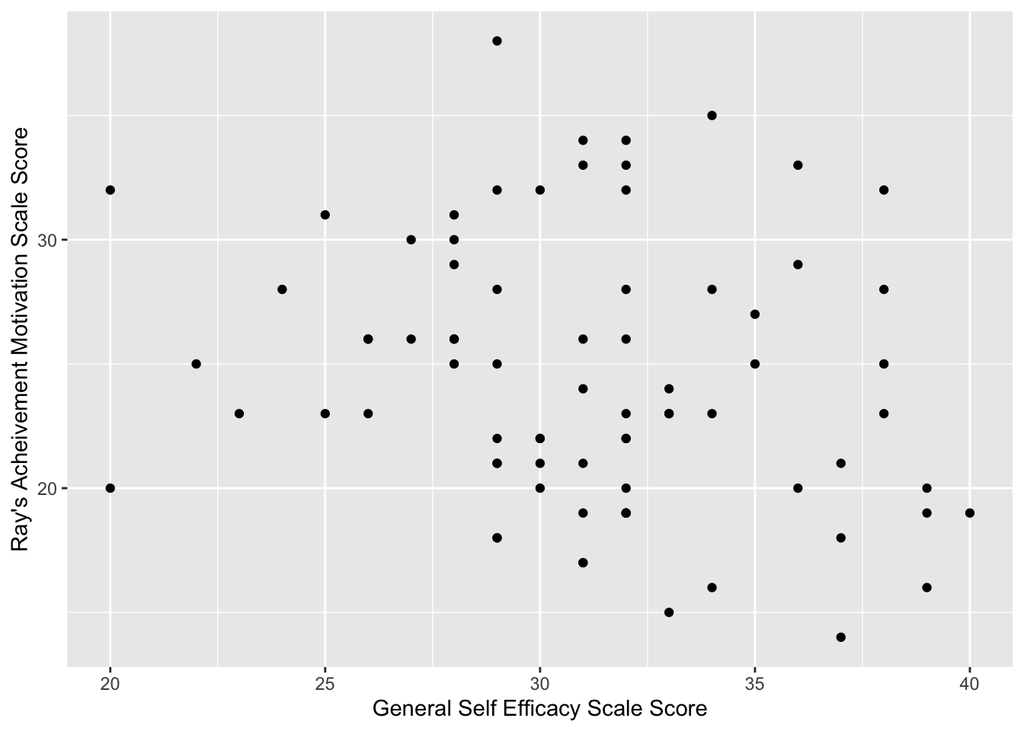

```r
# Scatterplots with labeled axes
ggplot(study_data, aes(x = GSE_scale, y = RAM_scale)) +
geom_point() +
labs(
x = "General Self Efficacy Scale Score",
y = "Ray's Acheivement Motivation Scale Score"
)
```

This section included the analyses of the effects of Academic Feedback type and Perceived Parental Warmth on self-efficacy.

### General Self Efficacy

```r
# 2x2 between-subjects ANOVA predicting Self-Efficacy scores
# DV: GSE_scale
# Factors: Condition and pwarmth
a1_GSE <- afex::aov_ez(
  id = "id",
  dv = "GSE_scale",
  between = c("Condition", "pwarmth"),
  data = study_data
  )
```

```
Converting to factor: Condition, pwarmth
```

```
Contrasts set to contr.sum for the following variables: Condition, pwarmth
```

```r
# Print the ANOVA table
a1_GSE
```

```
Anova Table (Type 3 tests)

Response: GSE_scale
             Effect    df   MSE    F  ges p.value
1         Condition 1, 68 18.37 0.70 .010    .405
2           pwarmth 3, 68 18.37 1.20 .050    .317
3 Condition:pwarmth 3, 68 18.37 2.04 .083    .117
---
Signif. codes:  0 '***' 0.001 '**' 0.01 '*' 0.05 '+' 0.1 ' ' 1
```

### Achievement Motivation

```r
# 2x2 between-subjects ANOVA predicting Achievement Motivation Scores
# DV: RAM_scale
# Factors: Condition and pwarmth
a1_RAM <- afex::aov_ez(
  id = "id",
  dv = "RAM_scale",
  between = c("Condition", "pwarmth"),
  data = study_data
  )
```

```
Converting to factor: Condition, pwarmth
```

```
Contrasts set to contr.sum for the following variables: Condition, pwarmth
```

```r
# Print the ANOVA table
a1_RAM
```

```
Anova Table (Type 3 tests)

Response: RAM_scale
             Effect    df   MSE    F   ges p.value
1         Condition 1, 68 29.87 0.05 <.001    .824
2           pwarmth 3, 68 29.87 1.88  .076    .142
3 Condition:pwarmth 3, 68 29.87 0.11  .005    .954
---
Signif. codes:  0 '***' 0.001 '**' 0.01 '*' 0.05 '+' 0.1 ' ' 1
```

## Marginal (Overall) Means

### Self-Efficacy

```r
# Marginal (group) means for parental warmth
# Averaged across levels of feedback condition
emmeans(a1_GSE, ~ pwarmth)
```

```
NOTE: Results may be misleading due to involvement in interactions
```

```
 pwarmth       emmean    SE df lower.CL upper.CL
 Authoritarian   31.1 0.810 68     29.5     32.7
 Authoritative   31.8 0.679 68     30.5     33.2
 Permissive      28.8 2.620 68     23.5     34.0
 Tie             28.5 1.960 68     24.6     32.4

Results are averaged over the levels of: Condition
Confidence level used: 0.95
```

```r
# Marginal (group) means for feedback condition
# Averaged across levels of parental warmth
emmeans(a1_GSE, ~ Condition)
```

```
NOTE: Results may be misleading due to involvement in interactions
```

```
 Condition emmean   SE df lower.CL upper.CL
 Autonomy    30.8 1.36 68     28.0     33.5
 Control     29.3 1.05 68     27.2     31.4

Results are averaged over the levels of: pwarmth
Confidence level used: 0.95
```

These estimated marginal means indicated that self-efficacy scores did not change significantly across both of the feedback conditions.

### Achievement Motivation

```r
# Marginal (group) means for feedback condition
# Averaged across levels of parental warmth
emmeans(a1_RAM, ~ Condition)
```

```
NOTE: Results may be misleading due to involvement in interactions
```

```
 Condition emmean   SE df lower.CL upper.CL
 Autonomy    25.7 1.74 68     22.2     29.1
 Control     25.2 1.34 68     22.5     27.8

Results are averaged over the levels of: pwarmth
Confidence level used: 0.95
```

```r
# Marginal (group) means for parental warmth
# Averaged across levels of feedback condition
emmeans(a1_RAM, ~ pwarmth)
```

```
NOTE: Results may be misleading due to involvement in interactions
```

```
 pwarmth       emmean    SE df lower.CL upper.CL
 Authoritarian   23.1 1.030 68     21.0     25.1
 Authoritative   25.0 0.865 68     23.3     26.7
 Permissive      24.5 3.350 68     17.8     31.2
 Tie             29.1 2.490 68     24.1     34.1

Results are averaged over the levels of: Condition
Confidence level used: 0.95
```

## Cell Means (Interaction Means)

### Self Efficacy

```r
#Raw estimated marginal means for each combination of condition and parental warmth
emmeans(a1_GSE, ~ Condition * pwarmth)
```

```
 Condition pwarmth       emmean    SE df lower.CL upper.CL
 Autonomy  Authoritarian   30.4 1.150 68     28.1     32.7
 Control   Authoritarian   31.8 1.150 68     29.5     34.1
 Autonomy  Authoritative   31.6 0.935 68     29.8     33.5
 Control   Authoritative   32.0 0.983 68     30.0     34.0
 Autonomy  Permissive      28.0 4.290 68     19.4     36.6
 Control   Permissive      29.5 3.030 68     23.5     35.5
 Autonomy  Tie             33.0 3.030 68     27.0     39.0
 Control   Tie             24.0 2.470 68     19.1     28.9

Confidence level used: 0.95
```

### Achievement Motivation

```r
#Raw estimated marginal means for each combination of condition and parental warmth
emmeans(a1_RAM, ~ Condition * pwarmth)
```

```
 Condition pwarmth       emmean   SE df lower.CL upper.CL
 Autonomy  Authoritarian   23.3 1.46 68     20.4     26.2
 Control   Authoritarian   22.9 1.46 68     19.9     25.8
 Autonomy  Authoritative   24.9 1.19 68     22.5     27.2
 Control   Authoritative   25.2 1.25 68     22.7     27.7
 Autonomy  Permissive      26.0 5.46 68     15.1     36.9
 Control   Permissive      23.0 3.86 68     15.3     30.7
 Autonomy  Tie             28.5 3.86 68     20.8     36.2
 Control   Tie             29.7 3.16 68     23.4     36.0

Confidence level used: 0.95
```

## Bar Plots

### Self Efficacy

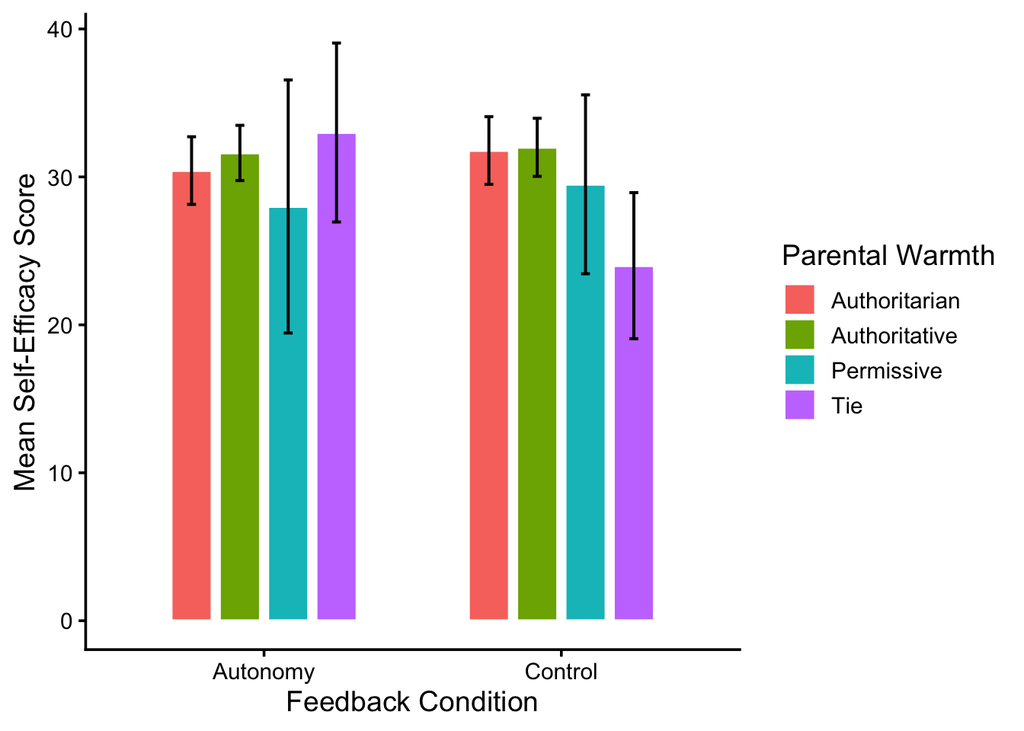

```r
p_GSE_bar <- ggplot(
  as.data.frame(emmeans(a1_GSE, ~ Condition * pwarmth)),
  aes(
    x = Condition,
    y = emmean,
    fill = pwarmth
  )
) +
  geom_col(
    position = position_dodge(width = 0.65),
    width = 0.55,
    color = "white"
  ) +
  geom_errorbar(
    aes(
      ymin = lower.CL,
      ymax = upper.CL
    ),
    position = position_dodge(width = 0.65),
    width = 0.12,
    linewidth = 0.7
  ) +
  labs(
    x = "Feedback Condition",
    y = "Mean Self-Efficacy Score",
    fill = "Parental Warmth"
  ) +
  theme_classic(base_size = 14)

print(p_GSE_bar)
```

**Figure 1**. This figure displays the cell means for self-efficacy across feedback condition and perceived parental warmth. Error bars represent 95% confidence intervals.

### Achievement Motivation

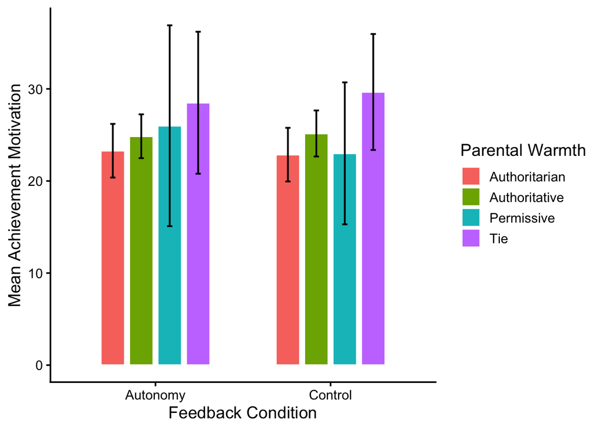

```r
p_RAM_bar <- ggplot(
  as.data.frame(emmeans(a1_RAM, ~ Condition * pwarmth)),
  aes(
    x = Condition,
    y = emmean,
    fill = pwarmth
  )
) +
  geom_col(
    position = position_dodge(width = 0.65),
    width = 0.55,
    color = "white"
  ) +
  geom_errorbar(
    aes(
      ymin = lower.CL,
      ymax = upper.CL
    ),
    position = position_dodge(width = 0.65),
    width = 0.12,
    linewidth = 0.7
  ) +
  labs(
    x = "Feedback Condition",
    y = "Mean Achievement Motivation",
    fill = "Parental Warmth"
  ) +
  theme_classic(base_size = 14)

print(p_RAM_bar)
```

#### Figure 2. **This figure displays the cell means for achievement motivation across the feedback condition and perceived parental warmth. The error bars represent 95% confidence intervals.**

## Save Plots

### Self-Efficacy

```r
# Create figures folder if needed
if (!dir.exists("figures")) dir.create("figures")
# Save whichever plots you want (SVG format for posters)
ggsave("figures/Self-Efficacy_bar_plot.svg", plot = p_GSE_bar, width = 7, height = 5)
```

#### Achievement Motivation

```r
# Create figures folder if needed
if (!dir.exists("figures")) dir.create("figures")
# Save whichever plots you want (SVG format for posters)
ggsave("figures/Achievement-Motivation_bar_plot.svg", plot = p_RAM_bar, width = 7, height = 5)
```

### Export Figures

Both interaction plots were exported as svg files to the figures folder for use in the final poster and report.

```r
if (!dir.exists("figures")) {
  dir.create("figures")
}

ggsave(
  filename = "figures/self_efficacy_interaction_plot.svg",
  plot = p_GSE_bar,
  width = 7,
  height = 5
)

ggsave(
  filename = "figures/achievement_motivation_interaction_plot.svg",
  plot = p_RAM_bar,
  width = 7,
  height = 5
)
```

## Results Summary

To conclude, the results of this study were not able to support our hypotheses. Participants who received autonomy-supportive feedback did not report higher self-efficacy or achievement motivation in comparison to those who received controlling feedback. Perceived parental warmth was not able to significantly influence self-efficacy or achievement motivation. To add on, the interaction between the feedback condition and parental warmth was not significant for both dependent variables, self-efficacy and achievement motivation. This suggests that parental warmth did not affect how students responded to the different types of academic feedback presented. These null findings may reflect the usage of a hypothetical feedback scenario or the absence of a elongated exposure to feedback that could potentially cause a meaningful change in self-efficacy and achievement motivation among students.